# Accessing Financial Reports and Corporate Events Data using GetDFPData

Marcelo Perlin, Guilherme Kirch, Daniel Vancin

Unisinos/Porto Alegre - January 19, 2018

# Introduction

# Motivation

- A look into past publications in Brazil:

Papers by Journal

| Journal | Surveyed | Total | Percent |
| --- | --- | --- | --- |
| Contabilidade Vista & Revista | 19 | 80 | 0.24 |
| Revista Brasileira de Finanças | 9 | 85 | 0.11 |
| Revista Contabilidade & Finanças | 34 | 118 | 0.29 |
| Revista Contabilidade e Organizações | 22 | 82 | 0.27 |
| Revista Contemporânea de Contabilidade | 21 | 112 | 0.19 |

# Features of `GetDFPData`

> **Made by researchers, to researchers**
- Provides a reference table with up to date information about companies:
  - available reports, sectors, governance listing segments, stock tickers
- Cleans and adjusts the data
  - Different accounting formats are merged using matching tools
  - Errors in the data are fixed, when possible, or discarted
- Always tabular format (*tidy data* principles (Wickham 2014)) and always the correct class in R
- R and web/shiny interface
- **Open and free!**

# Using `GetDFPData`

## The Web Interface

A web version was developed and published in the internet as a shiny application.

http://www.msperlin.com/shiny/GetDFPData/

# The R interface

## Installation of `GetDFPData`

1. Install R
2. Install RStudio
3. Install package

```r
# Release version in CRAN
install.packages('GetDFPData')
```

## Using `GetDFPData`

The starting point of `GetDFPData` is looking for information about current companies.

```r
library(GetDFPData)
library(tibble)

df.info <- gdfpd.get.info.companies(type.data = 'companies')
```

```
## Found cache file. Loading data..
```

```r
glimpse(df.info)
```

```
## Observations: 691
## Variables: 8
## $ name.company    <chr> "521 PARTICIPAÇOES S.A. - EM LIQUIDAÇÃO EXTRAJ...
## $ id.company      <int> 16330, 16284, 108, 20940, 21725, 19313, 18970,...
## $ situation       <chr> "ATIVO", "ATIVO", "CANCELADA", "CANCELADA", "A...
## $ listing.segment <chr> NA, "Tradicional", "Tradicional", "Tradicional...
## $ main.sector     <chr> NA, "Financeiro e Outros", "Materiais Básicos"...
## $ tickers         <chr> NA, "QVQP3B", NA, NA, "ADHM3", "AELP3", "TIET1...
## $ first.date      <date> 1998-12-31, 2001-12-31, 2009-12-31, 2009-12-3...
## $ last.date       <date> 2016-12-31, 2016-12-31, 2009-12-31, 2009-12-3...
```

The current number of active and inactive companies, as of 2018-01-19, is available in column `situation`. From it, we can see that there are 519 active companies and 167 cancelled.

We can also look at the distribution of sectors of traded companies at B3:

```r
t.sector <- table(df.info$main.sector)
print(as.data.frame(sort(t.sector, decreasing = TRUE)))
```

```
##                               Var1 Freq
## 1              Financeiro e Outros  145
## 2                  Consumo Cíclico   92
## 3                 Bens Industriais   80
## 4                Utilidade Pública   74
## 5                Materiais Básicos   47
## 6              Consumo não Cíclico   35
## 7                Não Classificados   28
## 8                            Saúde   18
## 9          Construção e Transporte   14
## 10 Petróleo. Gás e Biocombustíveis   13
## 11        Tecnologia da Informação   10
## 12                Telecomunicações    8
## 13 Petróleo, Gás e Biocombustíveis    2
```

The distribution of current governance listings is also available:

```r
t.listings <- table(df.info$listing.segment)
print(as.data.frame(sort(t.listings, decreasing = TRUE)))
```

```
##                             Var1 Freq
## 1                    Tradicional  359
## 2                   Novo Mercado  143
## 3 Corporate Governance - Level 1   27
## 4 Corporate Governance - Level 2   21
## 5                   Bovespa Mais   14
## 6         Bovespa Mais - Level 2    2
```

Tickers of companies are also available in column `tickers`. As an example, we can check all currently traded stocks of Gerdau:

```r
tickers.Gerdau <- df.info$tickers[which(df.info$name.company == 'GERDAU S.A.')]
print(tickers.Gerdau)
```

```
## [1] "GGBR3;GGBR4"
```

## Finding names of companies

Every company in the database can be identified by its official name. Function `gitrd.search.company` allow the user to search for the official name of a company.

Let’s find the *official* name of Ambev, one of the largest companies in Brazil:

```r
my.names <- gdfpd.search.company('ambev')
```

```
## Found cache file. Loading data..
##
## Found 2 companies:
## COMPANHIA DE BEBIDAS DAS AMÉRICAS-AMBEV | situation = CANCELADA | first date = 2010-12-31 | last date - 2012-12-31
## AMBEV S.A.                              | situation = ATIVO | first date = 2012-12-31 | last date - 2016-12-31
```

Its official name in Bovespa records is AMBEV S.A..

## Downloading financial information for one company

```r
name.companies <- 'AMBEV S.A.'
first.date <- '2012-12-31'
last.date  <- '2016-12-31'

df.reports <- gdfpd.GetDFPData(name.companies = name.companies,
                               first.date = first.date,
                               last.date = last.date)
```

```
## Found cache file. Loading data..
##
## First Date: 2012-12-31
## Laste Date: 2016-12-31
## Inflation index: dollar
##
##  Caching inflation RDATA into tempdir()  Done
##
## Inputs looking good! Starting download of files:
##
## AMBEV S.A.
##  Available periods: 2016-12-31   2015-12-31  2014-12-31  2013-12-31  2012-12-31
##
##
## Processing 23264 - AMBEV S.A.
##  Finding info from Bovespa
##      Found cache file DFP Cache Folder/23264_AMBEV S./GetDFPData_BOV_cache_23264_AMBE.rds
##  Processing 23264 - AMBEV S.A. | date 2016-12-31
##      Acessing DFP data | Found DFP cache file
##      Acessing FRE data | Found FRE cache file
##      Acessing FCA data | Found FCA cache file
##  Processing 23264 - AMBEV S.A. | date 2015-12-31
##      Acessing DFP data | Found DFP cache file
##      Acessing FRE data | Found FRE cache file
##      Acessing FCA data | Found FCA cache file
##  Processing 23264 - AMBEV S.A. | date 2014-12-31
##      Acessing DFP data | Found DFP cache file
##      Acessing FRE data | Found FRE cache file
##      Acessing FCA data | Found FCA cache file
##  Processing 23264 - AMBEV S.A. | date 2013-12-31
##      Acessing DFP data | Found DFP cache file
##      Acessing FRE data | Found FRE cache file
##      Acessing FCA data | Found FCA cache file
##  Processing 23264 - AMBEV S.A. | date 2012-12-31
##      Acessing DFP data | Found DFP cache file
##      Acessing FRE data | Found FRE cache file
##      Acessing FCA data | Found FCA cache file
```

The resulting object from `gdfpd.GetDFPData` is a `tibble`, a data.frame type of object that allows for list columns (Müller and Wickham 2017):

```r
glimpse(df.reports)
```

```
## Observations: 1
## Variables: 33
## $ company.name                  <chr> "AMBEV S.A."
## $ company.code                  <int> 23264
## $ company.tickers               <chr> "ABEV3"
## $ min.date                      <date> 2012-12-31
## $ max.date                      <date> 2016-12-31
## $ n.periods                     <int> 5
## $ company.segment               <chr> "Tradicional"
## $ current.stockholders          <list> [<c("AMBEV S.A.", "AMBEV S.A.",...
## $ current.stock.composition     <list> [<c("AMBEV S.A.", "AMBEV S.A.",...
## $ fr.assets                     <list> [<c("AMBEV S.A.", "AMBEV S.A.",...
## $ fr.liabilities                <list> [<c("AMBEV S.A.", "AMBEV S.A.",...
## $ fr.income                     <list> [<c("AMBEV S.A.", "AMBEV S.A.",...
## $ fr.cashflow                   <list> [<c("AMBEV S.A.", "AMBEV S.A.",...
```

[output cut: 20 more lines]

All financial statements for the different quarters are available within `df.reports`. For example, the income statements for all desired quarters of AMBEV are:

```r
df.income.long <- df.reports$fr.income[[1]]

glimpse(df.income.long)
```

```
## Observations: 130
## Variables: 6
## $ name.company       <chr> "AMBEV S.A.", "AMBEV S.A.", "AMBEV S.A.", "...
## $ ref.date           <date> 2016-12-31, 2016-12-31, 2016-12-31, 2016-1...
## $ acc.number         <chr> "3.01", "3.02", "3.03", "3.04", "3.04.01", ...
## $ acc.desc           <chr> "Receita de Venda de Bens e/ou Serviços", "...
## $ acc.value          <dbl> 20634193, -11263620, 9370573, 4006806, -399...
## $ acc.value.infl.adj <dbl> 6332420.75, -3456688.66, 2875732.09, 122964...
```

If desired, the wide format can be forced in the resulting financial reports with function `gdfpd.convert.to.wide`:

```r
temp.df <- dplyr::filter(df.income.long, ref.date >= as.Date('2015-01-31'))
df.income.wide <- gdfpd.convert.to.wide(temp.df)

knitr::kable(df.income.wide)
```

| acc.number | acc.desc | name.company | 2015-12-31 | 2016-12-31 |
| --- | --- | --- | --- | --- |
| 3.01 | Receita de Venda de Bens e/ou Serviços | AMBEV S.A. | 22106965 | 20634193 |
| 3.02 | Custo dos Bens e/ou Serviços Vendidos | AMBEV S.A. | -11431627 | -11263620 |
| 3.03 | Resultado Bruto | AMBEV S.A. | 10675338 | 9370573 |
| 3.04 | Despesas/Receitas Operacionais | AMBEV S.A. | 3371176 | 4006806 |
| 3.04.01 | Despesas com Vendas | AMBEV S.A. | -3591038 | -3999531 |
| 3.04.02 | Despesas Gerais e Administrativas | AMBEV S.A. | -1277065 | -1190964 |
| 3.04.03 | Perdas pela Não Recuperabilidade de Ativos | AMBEV S.A. | 0 | 0 |
| 3.04.04 | Outras Receitas Operacionais | AMBEV S.A. | 1974913 | 2631206 |
| 3.04.05 | Outras Despesas Operacionais | AMBEV S.A. | -530970 | -245490 |
| 3.04.06 | Resultado de Equivalência Patrimonial | AMBEV S.A. | 6795336 | 6811585 |
| 3.05 | Resultado Antes do Resultado Financeiro e dos Tributos | AMBEV S.A. | 14046514 | 13377379 |
| 3.06 | Resultado Financeiro | AMBEV S.A. | -1304158 | -2509282 |
| 3.06.01 | Receitas Financeiras | AMBEV S.A. | 3988762 | 2502321 |
| 3.06.02 | Despesas Financeiras | AMBEV S.A. | -5292920 | -5011603 |
| 3.07 | Resultado Antes dos Tributos sobre o Lucro | AMBEV S.A. | 12742356 | 10868097 |
| 3.08 | Imposto de Renda e Contribuição Social sobre o Lucro | AMBEV S.A. | -318585 | 1678513 |
| 3.08.01 | Corrente | AMBEV S.A. | 1920185 | 2157328 |
| 3.08.02 | Diferido | AMBEV S.A. | -2238770 | -478815 |
| 3.09 | Resultado Líquido das Operações Continuadas | AMBEV S.A. | 12423771 | 12546610 |
| 3.10 | Resultado Líquido de Operações Descontinuadas | AMBEV S.A. | 0 | 0 |
| 3.10.01 | Lucro/Prejuízo Líquido das Operações Descontinuadas | AMBEV S.A. | 0 | 0 |
| 3.10.02 | Ganhos/Perdas Líquidas sobre Ativos de Operações Descontinuadas | AMBEV S.A. | 0 | 0 |
| 3.11 | Lucro/Prejuízo do Período | AMBEV S.A. | 12423771 | 12546610 |
| 3.99 | Lucro por Ação - (Reais / Ação) | AMBEV S.A. | 0 | 0 |
| 3.99.01 | Lucro Básico por Ação | AMBEV S.A. | 0 | 0 |
| 3.99.02 | Lucro Diluído por Ação | AMBEV S.A. | 0 | 0 |

## Downloading financial information for several companies

`GetDFPData` is specially designed for handling large scale download of data. Let’s build a case with three randomly selected active companies:

```r
my.companies <- c("COMPANHIA CELG DE PARTICIPAÇÕES", "DOHLER S.A.", "KLABIN S.A.")

first.date <- '2012-01-31'
last.date  <- '2017-01-31'

df.reports <- gdfpd.GetDFPData(name.companies = my.companies,
                                  first.date = first.date,
                                  last.date = last.date)
```

And now we can check the resulting `tibble`:

```r
glimpse(df.reports )
```

```
## Observations: 3
## Variables: 33
## $ company.name                  <chr> "KLABIN S.A.", "COMPANHIA CELG D...
## $ company.code                  <int> 12653, 21393, 5207
## $ company.tickers               <chr> "KLBN11;KLBN3;KLBN4", "GPAR3", "...
## $ min.date                      <date> 2012-12-31, 2012-12-31, 2012-12-31
## $ max.date                      <date> 2016-12-31, 2016-12-31, 2016-12-31
## $ n.periods                     <int> 5, 5, 5
## $ company.segment               <chr> "Corporate Governance - Level 2"...
## $ current.stockholders          <list> [<c("KLABIN S.A.", "KLABIN S.A....
## $ current.stock.composition     <list> [<c("KLABIN S.A.", "KLABIN S.A....
## $ fr.assets                     <list> [<c("KLABIN S.A.", "KLABIN S.A....
## $ fr.liabilities                <list> [<c("KLABIN S.A.", "KLABIN S.A....
## $ fr.income                     <list> [<c("KLABIN S.A.", "KLABIN S.A....
## $ fr.cashflow                   <list> [<c("KLABIN S.A.", "KLABIN S.A....
```

[output cut: 20 more lines]

# A closer look at `gdfpd.GetDFPData`

Function `gdfpd.GetDFPData` provides many options to the user. Here we will describe and explain its features.

- **name.companies**: Official names of companies to get financial reports (e.g. ‘ELETROPAULO METROPOLITANA EL.S.PAULO S.A’).
- **first.date**: First date (YYYY-MM-DD) to download data. Character or Date. E.g. first.date = ‘2010-01-01’.
- **last.date**: Last date (YYYY-MM-DD) to download data. Character or Date. E.g. last.date = ‘2017-01-01’.
- **inflation.index**: Sets the inflation index to use for finding inflation adjusted values of all reports. Possible values are ‘dollar’ (default) or ‘IPCA’, the brazilian main inflation index. When using ‘IPCA’, the base date is set as the last date found in the DFP dataset.
- **max.levels**: Sets the maximum number of levels of accounting items in financial reports such as assets and liabilities (default = 3). If set to Inf, will return all available accounting itens.
- **folder.out**: Folder where to download and manipulate the zip files. Default = tempdir()
- **do.cache**: Logical for using a cache system or not. Default = TRUE
- **cache.folder**: Folder where to cache all processed information. Default = file.path(getwd(),‘DFP Cache Folder’)
- **max.dl.tries**: Maximum number of attempts for dowloading files

# Exporting financial data

The package also includes function `gdfpd.export.DFP.data` for exporting the financial data in the *Excel* or *csv* format.

Next we present an example of saving the output as an Excel file.

```r
my.basename <- 'MyExcelData'
my.type.export <- 'xlsx' # only supported so far

gdfpd.export.DFP.data(df.reports = df.reports,
                      base.file.name = my.basename,
                      type.export = my.type.export)
```

[output not shown]

# Usage Statistics of Shinny App

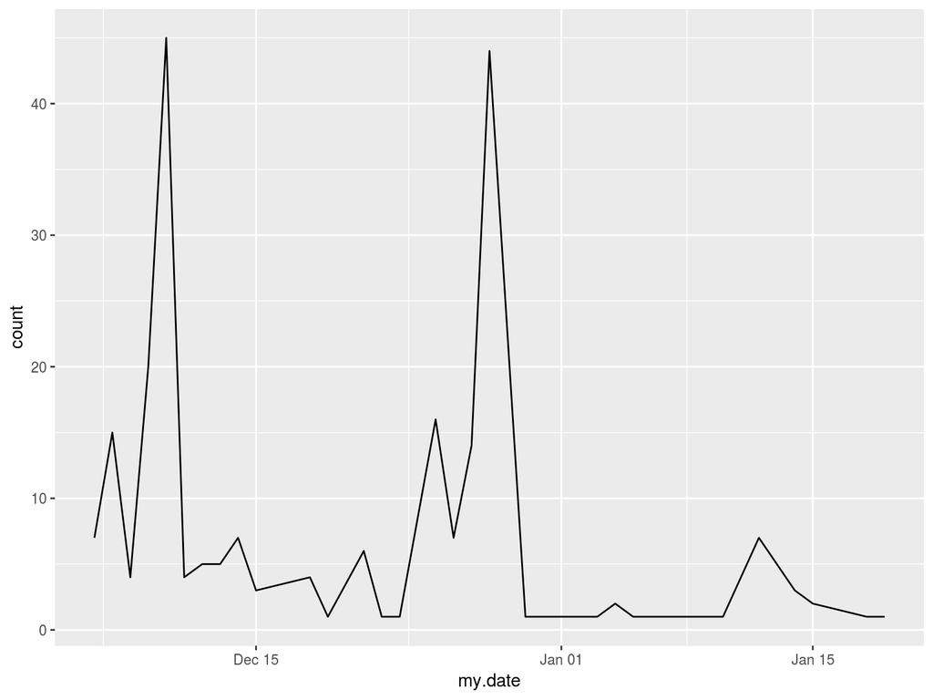

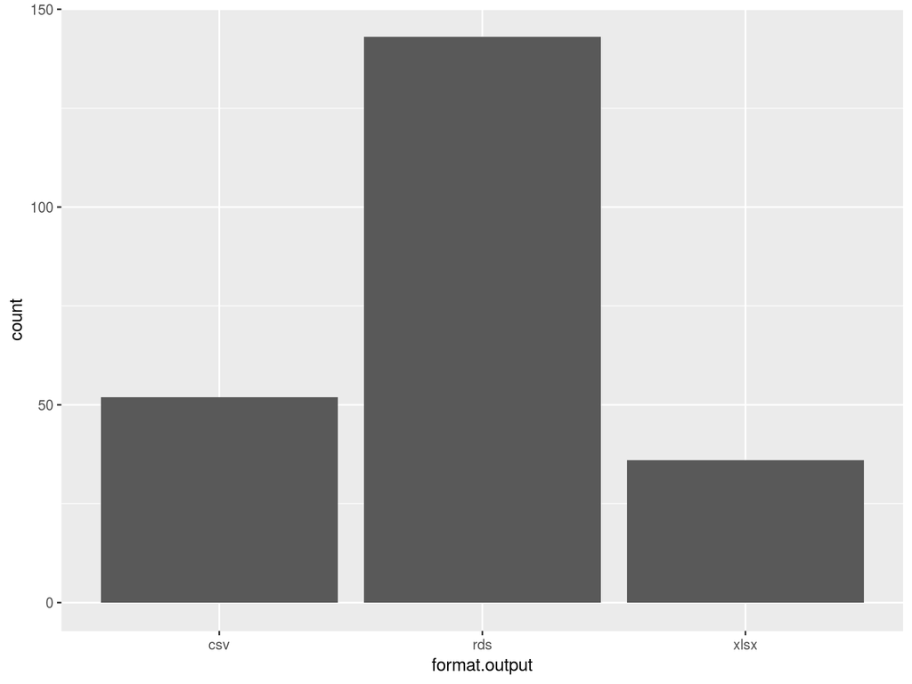

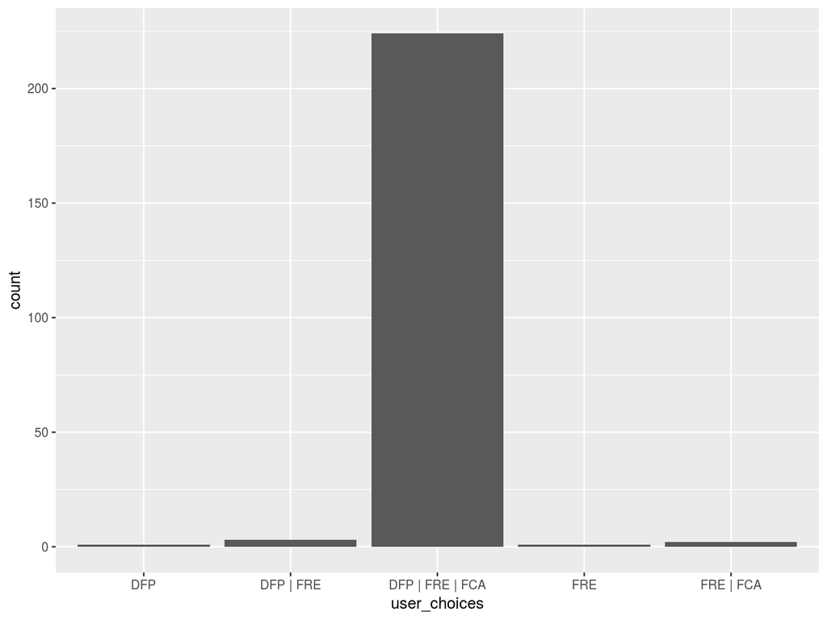

# Conclusions

- `GetDFPData` has a clear impact, facilitating access to a large dataset from B3
- Researchers will benefit with more time for research and less time for data acquisition and cleaning
- The software is in constant development

# References

Müller, Kirill, and Hadley Wickham. 2017. *Tibble: Simple Data Frames*. https://CRAN.R-project.org/package=tibble.

Wickham, Hadley. 2014. “Tidy Data.” *The Journal of Statistical Software* 59 (10). http://www.jstatsoft.org/v59/i10/.